# PGA Tour Project

Caleb Fornshell

11/11/2020

## *Introduction*

The emergence of data analytics has impacted the way sports are played across the world, and the PGA tour is no different. Over the last few years data has greatly impacted the way golfers play and how they are compared to one another. The goal of this project is to gain an understanding of which variables of a golfers performance are most important to determine whether a golfer will shoot low and win a tournament.

## *Gathering and Cleaning the Data*

The player performance data for this project was scraped from the official website of the PGA Tour, and the information on tournament winners is from Wikipedia. Both sources were scraped using Power Querey. The variables used were chosen based on my knowledge and interest of golf. In total, 14 variables were scraped from the PGA tour website and one from Wikipedia. One variable contained playerand year combined. These were split into two separate variables, which resulted in the variables used in this analysis. A full description of each variable can be found [here,](https://tinyurl.com/y4wljbxy) and the structure of data set is below.

```r
str(PGAdata)
```

```
## Classes 'spec_tbl_df', 'tbl_df', 'tbl' and 'data.frame': 940 obs. of  17 variables:
##  $ Golfer          : chr  "Aaron Baddeley" "Aaron Baddeley" "Aaron Baddeley" "Aaron Baddeley" ...
##  $ Year            : num  2015 2016 2017 2018 2019 ...
##  $ Player          : chr  "Aaron Baddeley (2015)" "Aaron Baddeley (2016)" "Aaron Baddeley (2017)" "Aaron Baddeley (2018)" ...
##  $ AvgApproachGT100: num  33.7 34.4 36.5 33.7 36.2 ...
##  $ AvgApproachLT100: num  19.1 18 17.2 19.4 16.5 ...
##  $ AvgBallSpeed    : num  175 173 173 171 171 ...
##  $ AvgClubheadSpeed: num  118 116 116 114 114 ...
##  $ LaunchAngle     : num  10.65 9.19 8.32 9.5 7.37 ...
##  $ ProxToHoleARG   : num  7.33 7.08 7.42 7.08 7.08 8.42 7.75 7.42 7.58 7.75 ...
##  $ Putt10_15Made   : num  44.8 33.5 33.9 27.6 36.9 ...
##  $ Putt15_20Made   : num  21.1 19.6 21 20.8 25 ...
##  $ PuttGT20Made    : num  6.91 7.19 6.1 5.67 7.39 7.47 6.08 6.83 6.8 8.98 ...
##  $ PuttLT10Made    : num  88.7 89.8 86 87.6 88.6 ...
##  $ SandSave        : num  59.1 61.1 58.4 57 54.5 ...
##  $ SpinRateOTT     : num  2526 2573 2875 2683 2858 ...
##  $ Winner          : num  1 0 0 0 0 1 0 0 0 0 ...
##  $ StrokeAverage   : num  71.2 70.9 71.5 70.8 70.8 ...
##  - attr(*, "spec")=
##   .. cols(
##   ..   Golfer = col_character(),
##   ..   Year = col_double(),
##   ..   Player = col_character(),
##   ..   AvgApproachGT100 = col_double(),
##   ..   AvgApproachLT100 = col_double(),
##   ..   AvgBallSpeed = col_double(),
##   ..   AvgClubheadSpeed = col_double(),
##   ..   LaunchAngle = col_double(),
##   ..   ProxToHoleARG = col_double(),
##   ..   Putt10_15Made = col_double(),
##   ..   Putt15_20Made = col_double(),
##   ..   PuttGT20Made = col_double(),
##   ..   PuttLT10Made = col_double(),
##   ..   SandSave = col_double(),
##   ..   SpinRateOTT = col_double(),
##   ..   Winner = col_double(),
##   ..   StrokeAverage = col_double()
##   .. )
```

This project uses two response variables, `StrokeAverage` and `Winner`, and twelve predictor variables which conceptually fall into one of three groups:

- Off the Tee Statistics
  - `AvgClubheadSpeed`, `AvgBallSpeed`, `LaunchAngle`, `SpinRateOTT`
- Shots Into the Green
  - `AvgApproachGT100`, `AvgApproachLT100`, `ProxToHoleARG`, `SandSave`
- Putting
  - `PuttGT20Made`, `Putt15_20Made`, `Putt10_15Made`, `PuttLT10Made`

## *Exploratory Data Analysis*

To begin, the numer of golfers from each year is determined. The barplot shows there were around 180-190 golfers from each season.

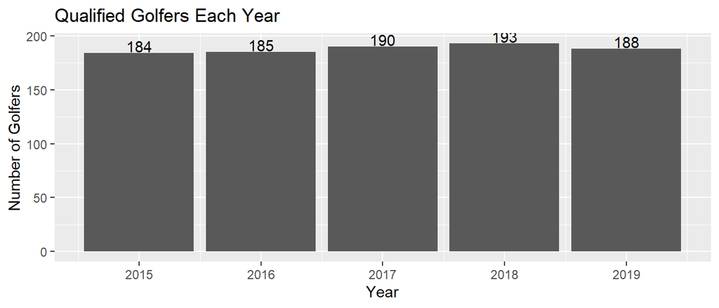

```r
#Number of qualified golfers each season
ggplot(data=PGAdata, aes(x=Year)) +
  geom_bar() +
  geom_text(stat='count',
            aes(label=..count..),
            vjust=-.1,
            position =position_dodge(width=.8)) +
  ylab("Number of Golfers")+
  labs(title = "Qualified Golfers Each Year")
```

Next, the distributions of the numeric variables were plotted and displayed. The histograms and summary statistics table show that these variables are symmetric and appear uni-modal. There are not any eye-catching anomalies that need to be addressed at this time.

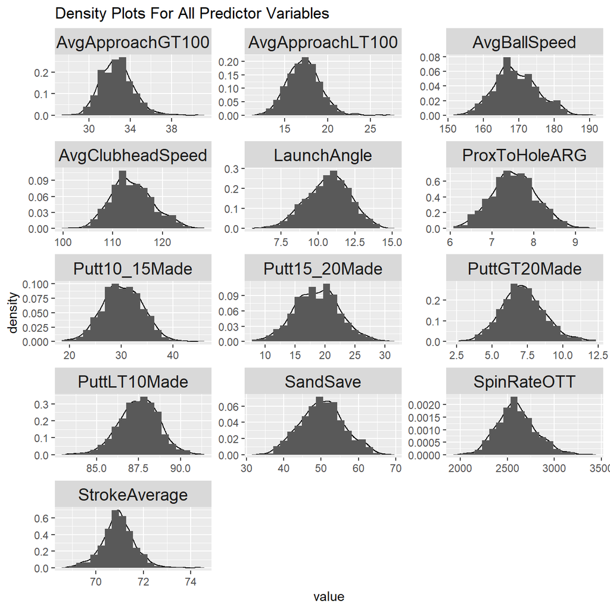

```r
# density and histogram of all predictor variables OTT
ggplot(data=melt(predStAvg), aes(x=value))+
  geom_density(color="black") +
  geom_histogram(aes(y = ..density..), bins=20 )+
  facet_wrap(~variable,scales = "free", ncol = 3)+
  labs(title = "Density Plots For All Predictor Variables") +
  theme(strip.text = element_text(size = 14))
```

```r
#summary statistics table
SummaryStats= tibble(Variable=names(predStAvg),
                     Units=c("Ft","Ft","MPH","MPH","Degrees","Ft",
                           "Perc","Perc","Perc","Perc","Perc","RPM","Strokes"),
                     Mean=round(apply(predStAvg,2,mean),2),
                     Median=round(apply(predStAvg,2,median),2),
                     Std.Dev=round(apply(predStAvg,2,sd),2),
                     Min=round(apply(predStAvg,2,min),2),
                     Max=round(apply(predStAvg,2,max),2))

#knitr::kable(SummaryStats,digits = 2)

SummaryStats
```

| Variable | Units | Mean | Median | Std.Dev | Min | Max |
| --- | --- | --- | --- | --- | --- | --- |
| AvgApproachGT100 | Ft | 32.69 | 32.58 | 1.58 | 27.42 | 40.58 |
| AvgApproachLT100 | Ft | 17.21 | 17.25 | 1.92 | 11.50 | 27.25 |
| AvgBallSpeed | MPH | 169.21 | 168.69 | 6.09 | 152.55 | 190.70 |
| AvgClubheadSpeed | MPH | 113.87 | 113.50 | 4.23 | 100.91 | 128.18 |
| LaunchAngle | Degrees | 10.68 | 10.78 | 1.47 | 5.57 | 14.71 |
| ProxToHoleARG | Ft | 7.54 | 7.50 | 0.54 | 6.08 | 9.33 |
| Putt10_15Made | Perc | 30.24 | 30.24 | 3.84 | 18.69 | 44.81 |
| Putt15_20Made | Perc | 18.67 | 18.73 | 3.74 | 8.00 | 30.63 |
| PuttGT20Made | Perc | 7.16 | 7.10 | 1.54 | 2.62 | 12.19 |
| PuttLT10Made | Perc | 87.50 | 87.57 | 1.19 | 83.12 | 91.18 |

[output cut: 3 more lines]

It is also important to understand the relationship between the predictor variables. The correlation plot below shows the linear relationship between all predictors. One pair of variables that has a very large positive correlation is `AvgClubheadSpeed` and `AvgBallSpeed`. This relationship, intuitivaley, is not surprising. There are also some negative correlations that are relatively high as well. These pair of variables will need to be considered in future analyses.

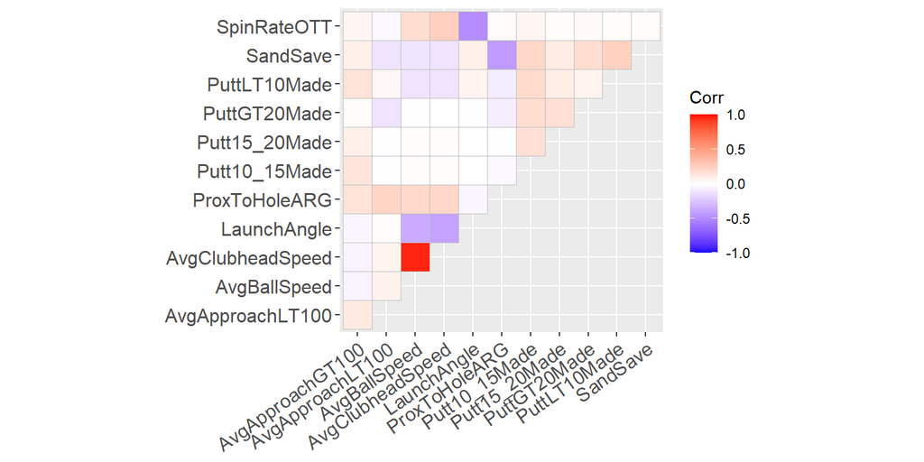

```r
ggcorrplot::ggcorrplot(cor(pred), method = "square", type = "upper", ggtheme = "minimal") +
  theme(axis.text.x=element_text(angle=35))
```

The EDA demonstrated that the data is complete and is not missing any values as the PGA kept thorough records for the seasons examined. Thus, there should be very issues in future analyses.

## *Predicting Stroke Average*

In the following section machine learning models will be used to predict a player’s stroke average based on the predictor variables described previously. A few different models such as K-nearest neighbors, regression trees, and random forests will be used. In an attempt to compare different models, the data will be split into training and test sets. The training data will be all observations from the seasons 2015-2018 and the test dataset will consist of observations from 2019.

```r
train = PGAdata[PGAdata$Year!=2019 , c(4:15,17)]
test = PGAdata[PGAdata$Year==2019 , c(4:15,17)]
```

In total ther are 752 observations in the training set and 188 observations in the test set.

### K-Nearest Neighbors

The first method used will the non-parametric method K-nearest neigbors(KNN). The package `caret` contains the `knnreg()`function implemented here. In these models the critical parameter is K, the number of neighbors. The chosen K will be the valuethat minimizes the MSE of the test data. The results of the model are shown in the graph below.

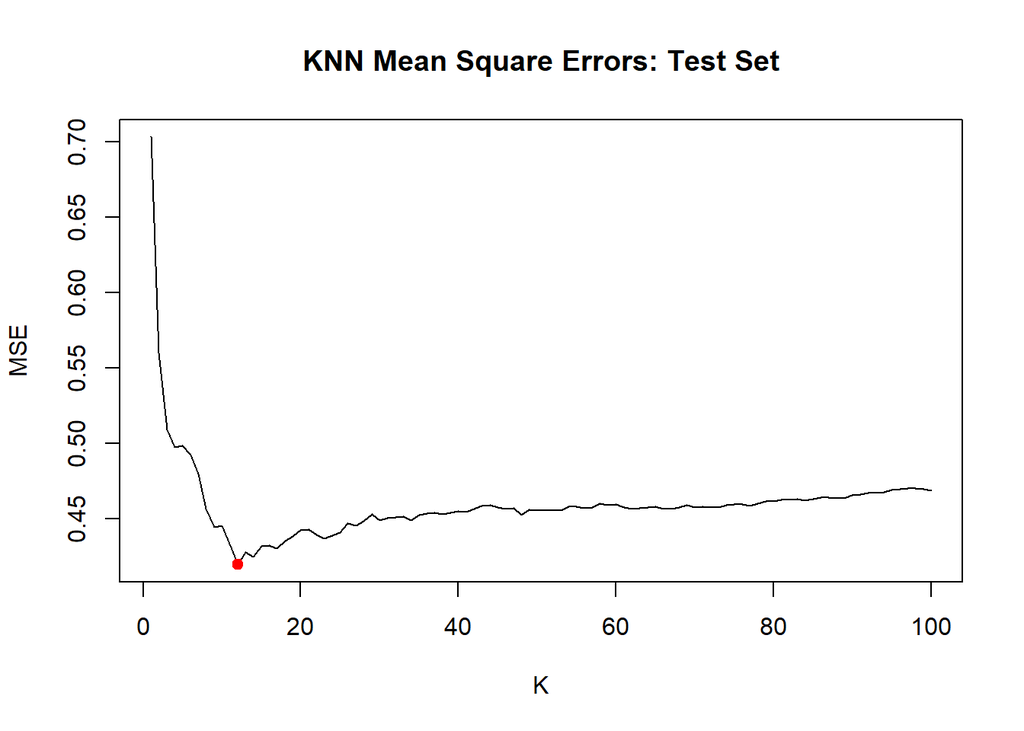

```r
#vector to store results
mse.vector = numeric(100)

#Will loop through all values of K and store the MSE. We want min(MSE)
for(i in 1:100){

knn.mod = knnreg(StrokeAverage~., data=train, k=i)#generating model with train
knn.test = predict(object = knn.mod, test)#getting predictions for test
MSE=mean((test$StrokeAverage - knn.test)^2)#calculating Test MSE

mse.vector[i]=MSE

}

#getting best K and MSE
bestk=which(mse.vector==min(mse.vector))
bestMSE.knn = min(mse.vector)

#Plot showing trend of test MSEs
plot(x=1:100, y=mse.vector, type = "l", xlab = "K", ylab = "MSE")
title("KNN Mean Square Errors: Test Set")
text(x=50, y=10,paste("Best: K=", bestk, "\nMin MSE=", round(bestMSE.knn,2)))
points(x=bestk, y=min(mse.vector), col="red", pch=19)
```

### Tree Based Methods

Regression trees are another non-parametric method. A simple regression tree and a random forrest will be implemented using the `tree` and `randomForest` packages.

#### *Regression Tree*

First, a simple tree. I will fit a simple tree model. Because there are a relatively large number of predictors, the tree will be “trimmed” using cross validation in the `prune.tree()` and `cv.tree()` functions and choosing the tree with 10 “leaves” minimizes the MSE on the test set.

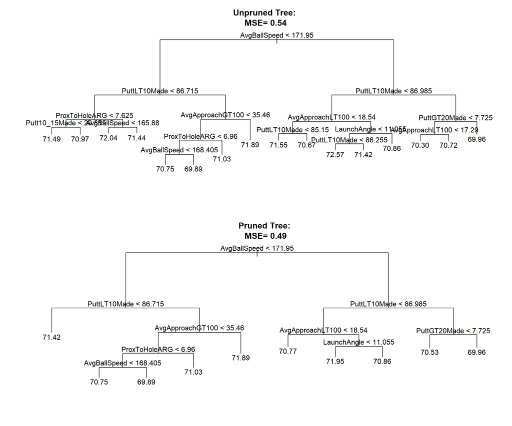

```r
set.seed(123)

##unpruned tree
unpruned.tree = tree(StrokeAverage~., data = train)
unpruned.pred = predict(unpruned.tree, test)
#MSE from the test set
unpruned.MSE = mean((unpruned.pred - test$StrokeAverage)^2)


# Pruned Tree chosen by Cross Validation
tree.cv = cv.tree(unpruned.tree, FUN = prune.tree)
#what is the optimal number of leaves
best.size = tree.cv$size[which(tree.cv$dev == min(tree.cv$dev))]#10
pruned.tree = prune.tree(unpruned.tree, best = best.size)
pruned.pred = predict(pruned.tree, test)
pruned.MSE = mean((pruned.pred - test$StrokeAverage)^2)

#plotting the Trees
par(mfrow=c(2,1))
plot(unpruned.tree)
title(paste("Unpruned Tree:\n MSE=", round(unpruned.MSE,2)))
text(unpruned.tree, pretty=0)

plot(pruned.tree)
title(paste("Pruned Tree:\n MSE=", round(pruned.MSE,2)))
text(pruned.tree, pretty=0)
```

#### *Random Forest*

Random forests are an improvement over a simple tree because it produces many uncorrelated trees which results in a smaller variance. It also restricts the variables that are available at each break in the tree, so it considers the effects of all variables even if they are correlated with best single predictor.

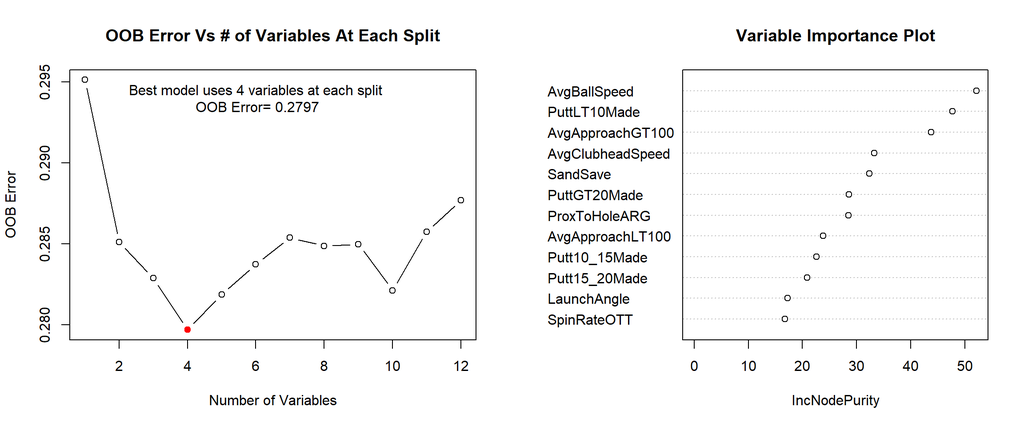

```r
set.seed(123)
forest.mse = numeric(12)

#finding tree that minimizes OOB error(MSE)
for(m in 1:12){

  #mtry = # of variables randomly selected at each break
  #trying to find best mtry
mod.forest = randomForest(StrokeAverage~., data=train, mtry=m)
forest.pred = predict(mod.forest, test)

forest.mse[m]=mean((forest.pred-test$StrokeAverage)^2)

}

best=which(forest.mse == min(forest.mse))

par(mfrow=c(1, 2))
plot(x=1:12, y=forest.mse,type="b",
     xlab = "Number of Variables", ylab = "OOB Error")
title(main = "OOB Error Vs # of Variables At Each Split")
text(paste("Best model uses", 4, "variables at each split\n",
           "OOB Error=", round(min(forest.mse),4)), x=6, y=.294)
points(x=best, y=min(forest.mse), pch=19, col="red")

varImpPlot(randomForest(StrokeAverage~., data=train, mtry=best),
           main = "Variable Importance Plot")
```

Another important feature with using tree based methods is it allows us to make a statement about which variables are most significant. The pruned and unpruned tree and the variable importance plot all have `AvgBallSpeed` as the upper most variable, so we can safely say that a higher `AvgBallSpeed` is an important factor in predicting `StrokeAverage`. All methods also have `PuttLT10Made` as the next highest variable, typically followed by some type of shot to the green.

### Comparison of Methods

The tables below show a comparison of the methods used above. Random forest was by far the best method based on minimizing the MSE. KNN, unpruned, and pruned regression trees all performed substantially worse. The bottom table compares the 2019 golfers’ stroke averages to those predicted by the forest table.

```r
tibble(Method = c("K-Nearest Neighbors", "Unpruned Regression Tree",
                  "Pruned Regression Tree", "Random Forest"),
       ImportantParameter = c("K", rep("Terminal Nodes",2), "mtry"),
       BestMSE = c(round(bestMSE.knn,2),round(unpruned.MSE,2),
                   round(pruned.MSE,2), round(min(forest.mse),4)))
```

| Method | ImportantParameter | BestMSE |
| --- | --- | --- |
| K-Nearest Neighbors | K | 0.4200 |
| Unpruned Regression Tree | Terminal Nodes | 0.5400 |
| Pruned Regression Tree | Terminal Nodes | 0.4900 |
| Random Forest | mtry | 0.2797 |

```r
SummTable=cbind(PGAdata %>%
             select(Year, Golfer, StrokeAverage) %>%
             filter(Year==2019), Predicted=round(forest.pred, 3)) %>%
  mutate(Error=abs(StrokeAverage - Predicted)) %>%
  arrange(Error)

SummTable
```

| Year | Golfer | StrokeAverage | Predicted | Error |
| --- | --- | --- | --- | --- |
| 2019 | Corey Conners | 70.777 | 70.780 | 0.003 |
| 2019 | J.T. Poston | 70.633 | 70.636 | 0.003 |
| 2019 | Bud Cauley | 70.574 | 70.563 | 0.011 |
| 2019 | Mackenzie Hughes | 70.907 | 70.920 | 0.013 |
| 2019 | Jason Day | 70.212 | 70.196 | 0.016 |
| 2019 | Jonathan Byrd | 71.490 | 71.472 | 0.018 |
| 2019 | Beau Hossler | 71.381 | 71.359 | 0.022 |
| 2019 | Adam Hadwin | 70.545 | 70.519 | 0.026 |
| 2019 | Brian Gay | 71.356 | 71.321 | 0.035 |
| 2019 | Ryan Blaum | 71.302 | 71.337 | 0.035 |

[output cut: 178 more lines]

## *Predicting Winners*

In professional sports, winning is everything. Based on the years 2015-2018, models to predict winners on the PGA tour can be constructed. The models constructed below won’t be used to predict winners of individual tournaments, but instead will classify a player based on if he should or shouldn’t have won a tournament in a particular year(predicting the value of variable `Winner`) based on the predictor variables used earlier and `StrokeAverage`. Three different models will be constructed and their accuracy examined.

### Logistic Regression

A logistic model will be used to determine the probability a golfer should have at least one victory in a year using the `glm()` function. The results of fitting a logistic model show that only some variables appear significant, so a simpler model using only those significant variables was also constructed.

```r
#setting up training and testing set
train = PGAdata[PGAdata$Year!=2019 , c(4:15,17,16)]
test = PGAdata[PGAdata$Year==2019 , c(4:15,17,16)]
train$Winner=as.factor(train$Winner)
test$Winner=as.factor(test$Winner)
```

```r
log.full = glm(Winner~., data=train, family="binomial")
summary(log.full)
```

```
##
## Call:
## glm(formula = Winner ~ ., family = "binomial", data = train)
##
## Deviance Residuals:
##     Min       1Q   Median       3Q      Max
## -1.6283  -0.5528  -0.3771  -0.2136   2.6385
##
## Coefficients:
##                    Estimate Std. Error z value Pr(>|z|)
## (Intercept)      93.7311739 23.5407448   3.982 6.84e-05 ***
## AvgApproachGT100 -0.1421038  0.0856585  -1.659   0.0971 .
## AvgApproachLT100 -0.0852134  0.0614581  -1.387   0.1656
## AvgBallSpeed     -0.1279860  0.0713736  -1.793   0.0729 .
## AvgClubheadSpeed  0.2456039  0.1026812   2.392   0.0168 *
## LaunchAngle       0.0247367  0.0959078   0.258   0.7965
## ProxToHoleARG     0.6216127  0.2560033   2.428   0.0152 *
## Putt10_15Made     0.0326956  0.0326756   1.001   0.3170
## Putt15_20Made     0.0300706  0.0319691   0.941   0.3469
## PuttGT20Made      0.0561272  0.0775961   0.723   0.4695
## PuttLT10Made      0.0733638  0.1112178   0.660   0.5095
## SandSave         -0.0075551  0.0234515  -0.322   0.7473
## SpinRateOTT      -0.0010718  0.0006697  -1.600   0.1095
## StrokeAverage    -1.4989650  0.2467491  -6.075 1.24e-09 ***
## ---
## Signif. codes:  0 '***' 0.001 '**' 0.01 '*' 0.05 '.' 0.1 ' ' 1
##
## (Dispersion parameter for binomial family taken to be 1)
##
##     Null deviance: 639.90  on 751  degrees of freedom
## Residual deviance: 515.22  on 738  degrees of freedom
## AIC: 543.22
##
## Number of Fisher Scoring iterations: 5
```

```r
log.simple = glm(Winner~AvgApproachGT100 + StrokeAverage + AvgClubheadSpeed +
                   AvgBallSpeed + ProxToHoleARG, data=train,
                 family="binomial")
summary(log.simple)
```

```
##
## Call:
## glm(formula = Winner ~ AvgApproachGT100 + StrokeAverage + AvgClubheadSpeed +
##     AvgBallSpeed + ProxToHoleARG, family = "binomial", data = train)
##
## Deviance Residuals:
##     Min       1Q   Median       3Q      Max
## -1.4974  -0.5691  -0.3840  -0.2147   2.6555
##
## Coefficients:
##                   Estimate Std. Error z value Pr(>|z|)
## (Intercept)      114.37437   16.30100   7.016 2.28e-12 ***
## AvgApproachGT100  -0.13220    0.08008  -1.651  0.09878 .
## StrokeAverage     -1.69624    0.22042  -7.696 1.41e-14 ***
## AvgClubheadSpeed   0.18940    0.09474   1.999  0.04561 *
## AvgBallSpeed      -0.10734    0.06697  -1.603  0.10896
## ProxToHoleARG      0.61742    0.22885   2.698  0.00698 **
## ---
## Signif. codes:  0 '***' 0.001 '**' 0.01 '*' 0.05 '.' 0.1 ' ' 1
##
## (Dispersion parameter for binomial family taken to be 1)
##
##     Null deviance: 639.90  on 751  degrees of freedom
## Residual deviance: 523.83  on 746  degrees of freedom
## AIC: 535.83
##
## Number of Fisher Scoring iterations: 5
```

The values of the coefficents demonstrate the most influential varibles appear to be similar to those found in the prediction of stroke average along with `StrokeAvgerage` itself. Probabilities of winning during the 2019 season, along with their confusion matrix are calculated below for both models. A golfer was predicted to have won if he had a probability greater than 0.40.

```r
#probabilities
full.pred = predict(log.full, test, type="response")
simple.pred = predict(log.simple, test, type="response")

full.win = (full.pred >= .4)
simple.win = (simple.pred >= .4)


#Confusion Matrices on test data
table(`Full Pred Win` = full.win + 1, `Actual Win` = as.numeric(test$Winner))
```

```
##              Actual Win
## Full Pred Win   1   2
##             1 153  25
##             2   3   7
```

```r
CCR.logF=round(mean(full.win +1 ==as.numeric(test$Winner))*100,2)
```

```r
table(`Simple Pred Win` = simple.win+ 1, `Actual Win` = as.numeric(test$Winner))
```

```
##                Actual Win
## Simple Pred Win   1   2
##               1 152  26
##               2   4   6
```

```r
CCR.logR= round(mean(simple.win +1 ==as.numeric(test$Winner))*100,2)
```

### Support Vector Machine

A support vector machine classifier was implemented using the `svm()` function from the `e1071` package. The confusion matrix of the best model is shown below.

```r
svmfit = svm(Winner~., data=train, kernel="radial", gamma=1, cost=1000)

#uses CV to select best model
tuned.svm = tune(svm, Winner~., data=train,
                kernel="radial", probability=TRUE,
                ranges=list(cost=c(.1,1,10,100),
                            gamma=c(.5,1,2,3)))

#predictions
svm.pred = predict(tuned.svm$best.model, test, probability = TRUE)
svm.win = attr(svm.pred, "p")[,1] >.4

CCR.svm = round(mean(svm.win +1 ==as.numeric(test$Winner))*100,2)
table(`Predicted Win` = svm.win + 1, `Actual Win` = as.numeric(test$Winner))
```

```
##              Actual Win
## Predicted Win   1   2
##             1 153  30
##             2   3   2
```

### Random Forest Classification

A random forest was also fit. The most accurate model selected considered ten variables at each branch and had the following variable importance plot.

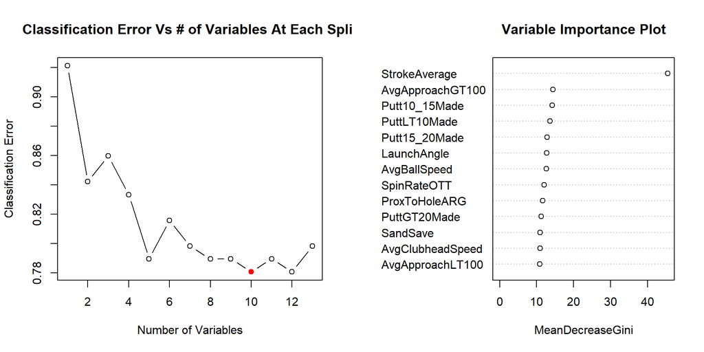

```r
set.seed(123)
forest.err = numeric(13)

#finding tree that minimizes OOB error(MSE)
for(m in 1:13){

  #mtry = # of variables randomly selected at each break
  #trying to find best mtry
mod.forest = randomForest(Winner~., data=train, mtry=m)
forest.pred = predict(mod.forest, test)

forest.err[m]=mod.forest$confusion[2,3]

}

best=min(which(forest.err == min(forest.err)))

par(mfrow=c(1, 2))
plot(x=1:13, y=forest.err,type="b",
     xlab = "Number of Variables", ylab = "Classification Error")
title(main = "Classification Error Vs # of Variables At Each Split")
text(paste("Best model uses", 4, "variables at each split\n",
           "OOB Error=", round(min(forest.err),4)), x=6, y=.294)
points(x=best, y=min(forest.err), pch=19, col="red")

varImpPlot(randomForest(Winner~., data=train, mtry=best),
           main = "Variable Importance Plot")
```

```r
best.forest=randomForest(Winner~., data=train)

forest.pred = predict(best.forest, test, cutoff = c(.6,.40))

table(`Predicted Win` = forest.pred, `Actual Win`=test$Winner)
```

```
##              Actual Win
## Predicted Win   0   1
##             0 150  26
##             1   6   6
```

```r
CCR.for = round(mean(forest.pred == test$Winner)*100,2)
```

The random forest classification shows that the most important variable is stroke average. This agrees with the summary table from the logistic regression models.

### Comparison of Methods

The comparison of correct classification rates shows that the accuracy for all models is around 80-85%. All models underestimated the number of golfers that win a tournament. The models were good at selecting the top ranked golfers in the world as demonstrated by the fact that golfers such as Brooks Koepka, Rory McIlroy, and Xander Schauffele were predicted by multiple models.

#### Classification Rates

```r
tibble(
  Method = c("Full Log. Regr.", "Reduced Log. Regr.", "SVM", "Random Forest"),
  `Correct Classification Rate` = c(CCR.logF, CCR.logR, CCR.svm, CCR.for))
```

| Method | Correct Classification Rate |
| --- | --- |
| Full Log. Regr. | 85.11 |
| Reduced Log. Regr. | 84.04 |
| SVM | 82.45 |
| Random Forest | 82.98 |

#### Predictions Vs. Observed

```r
summaryTab=cbind( PGAdata%>%filter(Year==2019)%>%select(Golfer, Winner) ,
       `Full Log.` = full.win*1,
       `Red. Log.` = simple.win*1,
       `SVM` = svm.win*1,
       `Rand. Forest` = as.numeric(forest.pred)-1)

summaryTab %>% arrange(desc(Winner))
```

| Golfer | Winner | Full Log. | Red. Log. | SVM | Rand. Forest |
| --- | --- | --- | --- | --- | --- |
| Adam Long | 1 | 0 | 0 | 0 | 0 |
| Brooks Koepka | 1 | 1 | 1 | 0 | 1 |
| Bryson DeChambeau | 1 | 0 | 0 | 0 | 0 |
| Cameron Champ | 1 | 0 | 0 | 0 | 0 |
| Charles Howell III | 1 | 0 | 0 | 0 | 0 |
| Chez Reavie | 1 | 0 | 0 | 0 | 0 |
| Corey Conners | 1 | 0 | 0 | 0 | 0 |
| Dustin Johnson | 1 | 0 | 0 | 0 | 0 |
| Dylan Frittelli | 1 | 0 | 0 | 0 | 0 |
| Francesco Molinari | 1 | 0 | 0 | 0 | 0 |

[output cut: 178 more lines]

## *Further Research*

In the future, other variables should also be studied to determine what are the best predictors of both `StrokeAverage` and `Winner`. The PGA website has a wide range of statistics and numerous possibilites exist to find the best combination. The prediction of `StrokeAverage` could probably be improved by incorporating more iron play statistics rather than just `AvgApproachGT100`, but overall the models were able to predict most golfer’s average to within a stroke and a half. The prediction of `Winner` was dominated by `StrokeAverage`. Perhaps determining better secondary predictors would increase accuracy. The models could also be improved by finding the optimal hurdle in deciding whether to predict the golfer as a winner because, in general the models predicted too few winners.